# 데이터 요청 보고서 — 관악 노드-링크 상관관계 분석 모듈

수신: 한국건설기술연구원(KICT) · 작성 2026-06-24 · 기준: **관악구(테스트베드) · 여름 우기(6~9월)** · 과업: **노드(맨홀)-링크(관로) 상관관계 분석 모듈**(위험기상 예측정보 노드 포함 · KICT 개발 알고리즘 기반)

관악 관망 GIS + 수위 센서로 **노드(맨홀)-링크(관로) 그래프를 구축·검증하고 상관관계 분석 모듈을 시제 구현**했으나, **노드 입력(위험기상 예측 × 집수면적)과 관측 밀도가 비어** 노드-링크 상관/전파 신호가 약했습니다. 본 보고서는 **그 진행 경과와 실패 사유를 정리하고, 모듈 완성에 필요한 데이터를 요청**합니다.

## 0. 과업 그래프 구조와 데이터의 관계

과업 = **노드-링크 상관관계 분석 모듈**(테스트베드 관악) — **노드=맨홀**(원자료 12,184개·그래프 노드 13,272개), **링크=관로**(상류→하류 유향, 관저고 기반, GIS 보유), **위험기상 예측정보 노드**(강우 예측을 맨홀별 유입으로 구조화), **분석=KICT 개발 알고리즘 기반** 네트워크에서 노드(맨홀수위)-링크(관로흐름) 상관관계 산출. 침수 라벨은 후속 *예측* 확장·검증용(선결조건 아님).

**숫자 기준**: 원자료 맨홀 시설물 **12,184개**와 그래프 노드 **13,272개**는 서로 다른 기준입니다. 그래프 노드는 관거의 시작·끝 맨홀 ID를 기준으로 구성한 모델 입력 단위입니다. 관거 레코드 중 엣지화 가능한 항목은 **16,059개**이고, 중복·정리 후 NetworkX 유향 그래프 기준 엣지는 **15,217개**입니다.

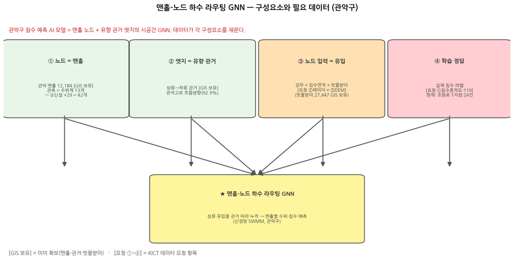

그림 0. 맨홀-노드 GNN 구성요소와 필요 데이터. 관망·맨홀·빗물받이(녹색)는 GIS로 확보, 요청 ①~④(주황·빨강)가 나머지를 채운다.

**골격은 개념이 아니라 이미 구축·검증됐습니다.** KICT 관악 관망 GIS의 **공식 연결(시작맨홀→끝맨홀)**로 그래프 노드 **13,272개**와 엣지화 가능 관거 레코드 **16,059개**를 구성했습니다. 이 중 중복·정리 후 NetworkX 유향 그래프 기준 엣지는 **15,217개**입니다. 공식 **접속관수로 교차검증(차수 정확 80%·±1 91%)**·**공간정합 77%**(나머지 플래그, 완전검증판=SWMM)했고, 공식 경사·소유역(집수단위 40)도 부착했습니다. 비어있는 건 입력·정답뿐입니다.

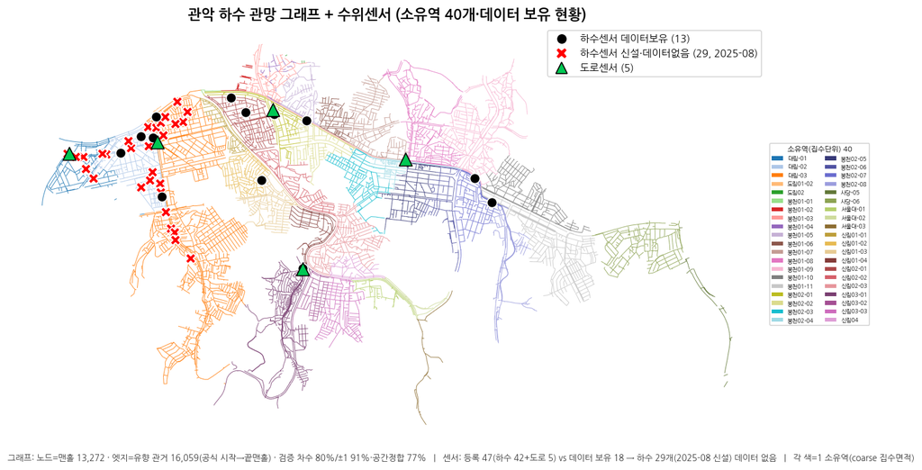

그림 0b. 관악 하수 관망 그래프 + 수위센서(통합). 노드=맨홀 13,272·엣지=유향 관거 16,059(차수검증 80%·±1 91%·공간정합 77%). **각 색=1 소유역(집수단위 40, coarse 집수면적=③ 근거)**. 센서: 하수 데이터보유 13(검은 원)·신설 29(빨간 X, 2025-08)·도로 5(녹색 삼각) — **등록 47 vs 보유 18**.

이 그래프 위에 **맨홀-노드 STGNN을 실제 구현·시험**했습니다. 다만 **13,272개 맨홀 중 관측은 13개뿐**이라 나머지는 입력이 비어 있는 통과(relay) 노드로 남고, 그래서 그래프 전파 효과가 아직 미미합니다 — relay 노드를 채울 **맨홀별 유입(②레이더 강우 × ③집수면적)**이 그래프가 실제로 신호를 전파하기 위한 직접 조건입니다.

관망·맨홀(노드-링크 골격)은 이미 확보·구축·검증됨. **빈 곳은 ②위험기상 예측정보 ③집수면적 ④관측 노드**(상관관계 분석 모듈 입력) · **①침수 라벨은 후속 예측 확장용** → 아래 요청이 각각을 채웁니다.

## 1. 진행 경과와 미완(실패) 사유 (관악·여름)

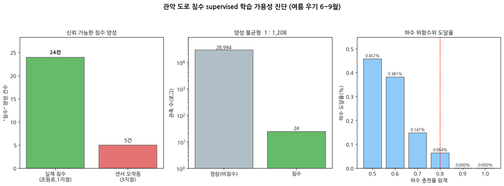

그림 1. 관악 도로 침수 supervised 학습 가용성. 신뢰 양성 조원로 24건(1지점)·불균형 1:1,208·하수 위험수위 도달 0.064%.

센서 인프라는 충분하나 데이터가 부족: **등록 47(하수 42+도로 5) vs 데이터 보유 18** — 하수 29개(2025-08 신설)는 관망 위에 있으나 데이터 없음(그림 0b 참조).

## 2. 요청 데이터

**상관관계 분석 모듈 기준 우선순위: ②·③(노드 입력) → ④(관측 밀도) → ①(예측 확장·검증)**

| 우선순위 | 요청 데이터 | 채우는 구성요소 | 없을 때 병목 | 최소 제공 형태 |
| --- | --- | --- | --- | --- |
| ② | 위험기상 예측정보(격자 강우) | 노드 입력(강우) | 점강우·수위이력은 리드타임 부족 | 격자ID·시간·강수량·좌표계·결측코드 |
| ③ | SWMM/DEM | 노드 입력(집수면적) | 강우를 맨홀별 유입량으로 변환 불가 | SWMM .inp 또는 DEM/LiDAR |
| ④ | 신설 하수 수위계 | 관측 노드 밀집 | 관측 노드 13개로 공간 검증 제한 | 21-0014~0042, 1·10분 수위, 2025-09~현재 |
| ① | 침수 정답 라벨 | 예측 확장·검증(후순위) | 모듈을 예측으로 확장 시 정답지 부재 | 발생일시·위치·침수심/유형(비식별 가능) |

### ② 위험기상 예측정보 노드 = 격자(레이더형) 강우 노드 입력(강우) · 리드타임의 본체

**요청**: 이동하는 강우장을 담은 **격자 강수자료** — 기상청 레이더 합성(HSR 등)·KICT 보정 강수장 등 가용한 것이면 됨  
**명세**: **기능 요건**: 점이 아닌 공간 격자 · 관악을 해상하기 충분한 해상도(예: 1km 이하) · 시간 5~10분급 · 상류 포함 영역(이동 관측) · 2024~현재 · 좌표계/격자ID/강수단위/결측코드. **※기상청 HSR(500m·5분)은 충족 예시일 뿐 필수 규격 아님** — 동등한 격자자료면 가능  
**사유**: 리드타임은 모델이 만드는 게 아니라 '미래를 담은 입력'에서 나옴. 두 개의 시계 중 **(가) 기상 시계**(비가 아직 관악에 안 옴)만 10~60분 선행을 줌 = 레이더. 관악 **(나) 수문 시계**(유출 지연)는 거의 0(강우-수위 동시반응, persistence 0.72 ≫ GNN 0.17)이라 그래프만으론 몇 분뿐 → **레이더가 리드타임의 본체**. 점 강우는 리드타임 0(빗방울이 강우계 때리는 순간 이미 온 것). [정직한 한계] 관악 침수=국지 대류 호우는 nowcasting이 가장 약한 유형(이동뿐 아니라 생성·소멸)이라 리드타임 천장은 보수적(현실 10~30분). 구조: 레이더 강우장 → nowcast → 예측 강우장 → ×집수면적 → 맨홀 유입 → 유향 GNN(2단 분리).

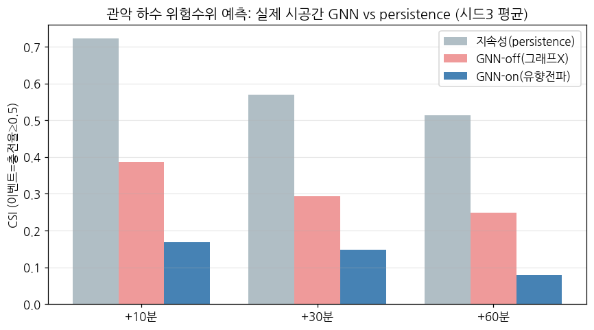

그림 3. 관악 시공간 GNN. 현재 입력(수위 이력·점강우)만으로는 persistence(0.72/0.57/0.51)를 넘지 못함 = 조기 입력 리드타임 부재 → 레이더 필요.

### ③ DEM (수치표고) — 또는 KICT 하수관망 수리모델(SWMM) 모델: 노드 입력(집수면적)

**요청**: 고해상 DEM/LiDAR **또는** KICT 보유 하수관망 수리모델(SWMM 등, 소배수구역·맨홀별 집수면적 포함) — 둘 중 하나  
**명세**: 1순위: SWMM .inp/수리모델(소배수구역·맨홀별 집수면적 포함) · 대안: DEM/LiDAR 1m급 또는 가용 최고해상  
**사유**: 모델 노드 입력 = 맨홀 유입량 = **강우 × 집수면적**(합리식 Q=C·i·A). 강우(②)만으론 유입 부피가 안 나오고, 면적이 곱해져야 '실제 들어오는 물의 양'이 됨. 같은 비라도 집수면적 큰 맨홀이 먼저 위험 → 공간 위험 구분에 면적 가중 필수. **GIS 소유역은 40개로 coarse**(이미 활용) → 맨홀별 정밀 집수면적은 DEM(흐름누적·저지대)에서 도출하거나 SWMM이 있으면 그대로 사용.

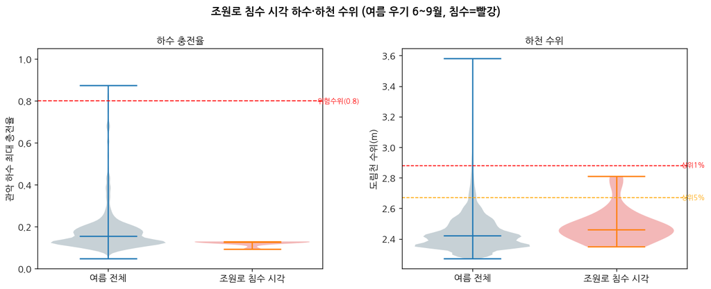

그림 4. 조원로 침수 시각 하수·하천 수위(여름). 침수 때 하수(위험수위 미달)·하천(평상시) 모두 정상 → 표면류.

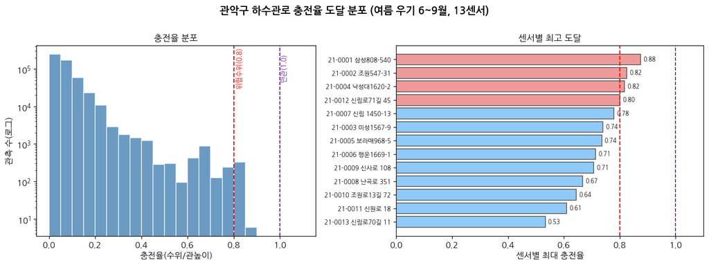

그림 5. 관악 하수관로 충전율 도달 분포(여름). 위험수위(0.8) 도달 극소·만관(1.0) 0개 = 하수 신호 부재(=하수 만관 가설 기각).

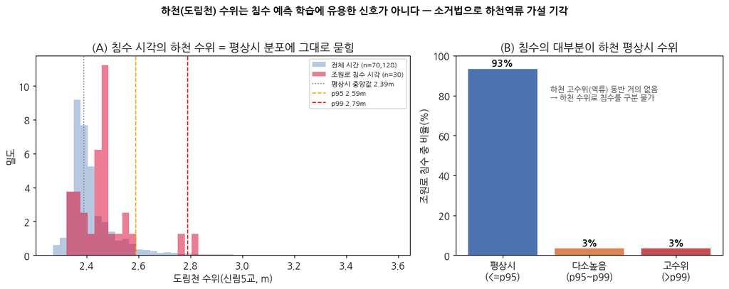

### ④ 관악 신설 하수 수위계 시계열 모델: 관측 노드 밀집

**요청**: 관악 신설 하수 수위계 29개(21-0014~0042, 2025-08~) 및 이후 최신 기간 시계열  
**명세**: 수위계 21-0014~0042 · 1·10분 수위 · 2025-09~현재  
**사유**: 2026년 우기 실시간 검증과 semi-supervised 관측 밀도 확보에 필요. 관측 노드가 13→42(3배)로 늘며, 이미 수집 중인 시계열이라 제공 비용이 낮음. 우리 데이터는 2025-08-31까지라 2025-09 이후 신설분도 미보유.

(그림 0b 참조)

### ① 침수 정답 라벨 후순위: 예측 확장·검증용

**요청**: KICT 침수 검증(ground-truth) 데이터 · 관악 침수흔적도 · 120/119 침수신고  
**명세**: 침수흔적도 SHP(발생일자 포함) · 120/119 신고(비식별화 가능: 일시·좌표/주소·침수심/피해유형) · 가능 연도(2020·2022 대홍수 포함 희망)  
**사유**: **상관관계 분석 모듈의 선결조건은 아님(후순위)**. 단 모듈을 *예측*으로 확장·검증하려면 검증된 정답지 필수 — 관악 깨끗한 양성이 1지점·24건이라 현 데이터로는 예측 검증 불가.

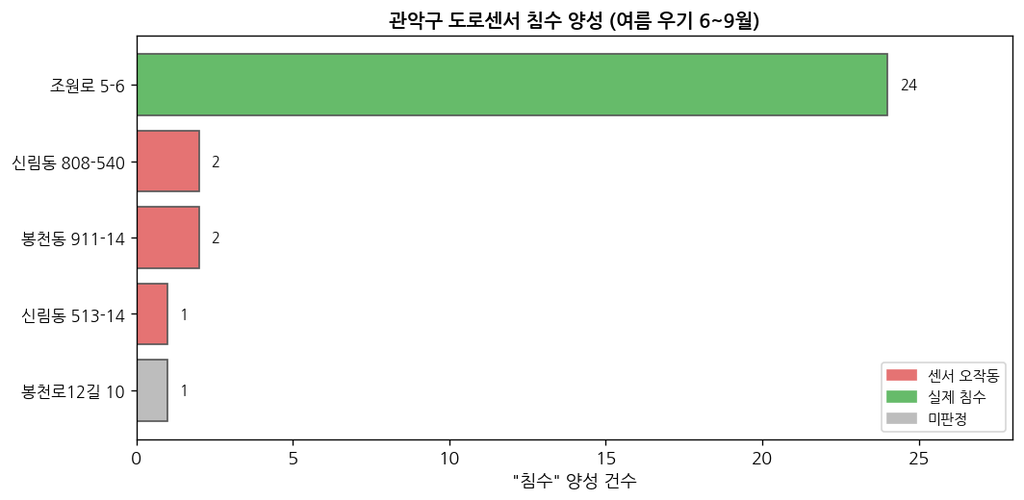

그림 2. 관악 도로센서 침수 양성(여름). 실제 침수=조원로 24, 나머지는 센서 오작동/미판정.

## 3. 데이터 수신 후 활용 계획

| 단계 | 작업 | 산출물 |
| --- | --- | --- |
| 1 | 좌표계·시간축·센서 ID를 기존 관망 그래프와 정합 | 정합 테이블, 품질 점검표 |
| 2 | 위험기상 예측정보와 집수면적을 결합해 맨홀별 유입(노드 입력) 생성 | 맨홀별 유입 시계열 |
| 3 | KICT 알고리즘 기반 네트워크에서 노드-링크 상관관계 분석 모듈 산출 | 노드-링크 상관/전파 지표 |
| 4 | (예측 확장 시) 침수 라벨로 persistence 대비 성능 검증 | CSI·POD·FAR·리드타임 비교 |

**부분 제공 시 우선순위**: 상관관계 분석 모듈은 ②위험기상 예측정보·③집수면적(노드 입력)과 ④관측 밀도가 먼저 채워져야 노드-링크 신호가 드러납니다. ①침수 라벨은 이후 예측 확장·검증 단계에서 필요합니다.

## 4. 회신 요청 (방향 정렬)

1. **KICT 개발 알고리즘**(네트워크 설계 근거) 명세·문서 공유 — 맨홀-노드 유향그래프와의 정합 확인.
2. **위험기상 예측정보**의 정의·제공 형식(레이더 격자 / 초단기예측 / 특보 중 무엇인지).
3. KICT ground-truth 침수 검증 보유 여부(후속 *예측* 확장·모듈 검증용 — 이미 보유 시 ① 해소).
4. 관악 신설 29센서 제공 가능 여부·형식 · 하수관망 수리모델(SWMM)/고해상 DEM 보유 여부.

관망·맨홀(노드-링크 골격)은 확보·검증됨. **②위험기상 예측정보·③집수면적·④관측 밀도가 상관관계 분석 모듈을 완성**하고, ①침수 라벨은 이후 *예측* 확장의 정답지입니다.

## 5. 별도 정리용 문장 모음

**요약**: 관악 관망 GIS와 수위 센서로 노드(맨홀)-링크(관로) 그래프를 구축·검증하고 상관관계 분석 모듈을 시제 구현했으나, 노드 입력(위험기상 예측 × 집수면적)과 관측 밀도가 비어 노드-링크 상관/전파 신호가 약했습니다. 따라서 본 요청은 추가 자료 수집이 아니라, 이미 구축된 노드-링크 그래프의 빈 입력을 채워 상관관계 분석 모듈을 완성하기 위한 최소 데이터 요청입니다.

**숫자 기준**: 본 보고서의 맨홀 수와 그래프 노드 수는 서로 다른 기준입니다. 원자료 맨홀 시설물은 12,184개이며, 관거의 시작·끝 맨홀 ID를 기준으로 그래프화하면 노드 13,272개가 생성됩니다. 관거 레코드 중 엣지화 가능한 항목은 16,059개이고, 중복·정리 후 NetworkX 유향 그래프 기준 엣지는 15,217개입니다.

**레이더 강우**: 리드타임은 모델이 만들어내는 것이 아니라, 미래를 담은 입력에서 나옵니다. 침수 사건의 시간 여유는 두 개의 시계로 나뉩니다 — **기상 시계**(비가 아직 관악에 도달하지 않음)와 **수문 시계**(비는 내렸으나 아직 유출·월류 전). 관악은 도시 소유역이 작아 수문 시계가 거의 0이며(강우-수위가 동시 반응, persistence 0.72 ≫ GNN 0.17), 따라서 유향 그래프만으로 버는 리드타임은 몇 분에 불과합니다. 의미 있는 10~60분 리드타임의 본체는 **기상 시계 = 레이더**입니다. 레이더는 공간적으로 이동하는 강우장을 상류에서 먼저 관측하므로 맨홀별 유입을 시간적으로 앞서 입력합니다. 점 강우계는 빗방울이 계기를 때리는 순간 이미 비가 온 것이라 리드타임이 0입니다. 다만 정직하게, 관악 침수형인 국지 대류 호우는 셀이 이동만 하는 것이 아니라 그 자리에서 생성·소멸하므로 nowcasting이 가장 어려운 유형이며, 리드타임 천장은 보수적으로 10~30분 수준으로 봅니다. 구현은 [레이더 강우장 → nowcast → 예측 강우장 → ×집수면적 → 맨홀 유입 → 유향 GNN]의 2단 구조로 분리하여, 강우 예측 단과 침수 라우팅 단을 독립적으로 검증·교체할 수 있게 설계합니다.

**SWMM/DEM**: 맨홀-노드 GNN의 노드 입력은 단순 강우량이 아니라 맨홀별 유입량입니다. 유입량은 강우강도에 집수면적이 곱해져야 산정되므로, 같은 비가 내려도 집수면적이 큰 맨홀은 더 빨리 위험 상태에 도달할 수 있습니다. 따라서 SWMM 등 수리모델이 있으면 가장 직접적으로 활용 가능하며, 없을 경우 고해상 DEM/LiDAR를 통해 맨홀별 집수면적을 추정해야 합니다.

**신설 센서**: 관악구 신설 하수 수위계 29개는 즉시 침수 라벨을 대체하지는 않지만, 2026년 우기 검증과 semi-supervised 관측 노드 확대에 중요합니다. 제공 시 관측 가능한 하수 노드가 13개에서 42개로 약 3배 확대되어, 관망 위 수위 전파와 국지 반응 검증의 공간 해상도가 개선됩니다.

**실행 계획**: 데이터 수신 후에는 먼저 좌표계·시간축·센서 ID를 기존 관망 그래프와 정합하고, 침수 라벨을 맨홀/도로 단위 학습 정답으로 변환합니다. 이후 레이더 강우와 집수면적을 결합해 맨홀별 유입량 입력을 만들고, 기존 GNN 하네스에서 persistence 대비 CSI·POD·FAR·리드타임 개선 여부를 재평가하겠습니다.

**비식별 제공**: 120/119 신고 등 개인정보가 포함될 수 있는 자료는 개인 식별정보를 제거한 형태로도 충분히 활용 가능합니다. 모델 학습에는 신고자 정보가 필요하지 않으며, 일시·공간 위치·침수 유형 또는 침수심 정보만 있으면 정답 라벨로 변환할 수 있습니다.

근거 수치 재현: `python scripts/data_request_rationale.py`